# R Notebook

```r
library(prob)
library(tidyverse)
```

# Uniform Probability distribution

Where every outcome has the same likelihood of occuring. e.g. where our coins are not biased.

```r
s_three_coins <- tosscoin(3)
s_three_coins
```

```r
s_three_coins <- s_three_coins %>%
  mutate(label = str_c(toss1, toss2, toss3, sep = "")) %>%
  mutate(prob = 1 / n())

s_three_coins %>%
  ggplot(aes(x = label, y = prob)) +
  geom_col() +
  xlab("coin toss result") +
  ylab ("prob of each outcome")
```

[output not shown]

# Plot number of heads

```r
s_three_coins <- s_three_coins %>%
  mutate(
    num_heads = rowSums(. == "H")
  )

prob_num_heads <- s_three_coins %>%
  group_by(num_heads) %>%
  summarise(prob = sum(prob))

prob_num_heads %>%
  ggplot() +
  aes(x = num_heads, y = prob) +
  geom_col() +
  xlab("Number of heads") +
  ylab("Probability")
```

[output not shown]

# Measures of Centre

```r
library(janitor)
library(lubridate)
```

```r
air_con_sales <- read_csv("data/AirConSales.csv") %>%
  clean_names() %>%
  mutate(date = as_date(date, format = "%m/%d/%Y"))
```

# Find the distribution of units sold per day

```r
# col 2 = frequency e.g. 9 days where 3 units were sold
# Col 3 equals relative frequency: the proportion of days where 3 units were sold
sales_frequency_table <- air_con_sales %>%
  tabyl(units_sold)
```

# Plot distribution of air con unit sales

```r
sales_frequency_table %>%
  ggplot() +
  aes(x = units_sold, y = percent) +
  geom_col()
```

[output not shown]

# Summarising distribution

## Mean

| mean_daily_sales |
| --- |
| 5.945946 |

## Median

The value where half of values are smaller than and half of the values are bigger than it

| median_daily_sales |
| --- |
| 4 |

## Mode

The value which occurs most frequently

| mode_daily_sales |
| --- |
| 3 |

# Effects of outliers

| mean_daily_sales | median_daily_sales | mode_daily_sales |
| --- | --- | --- |
| 5.945946 | 4 | 3 |

Outliers have significant impact on mean value

| mean_daily_sales | median_daily_sales | mode_daily_sales |
| --- | --- | --- |
| 4.916667 | 4 | 3 |

# Desciribing disributions

## Unimodal and Bimodal Distributions

Uniform - flat - no peaks Unimodal - one most common value e.g. one peak in distribution Bimodal - exactly two peaks Multimodal - more than two peaks

```r
bimodal <- read_csv("data/bimodal.csv")
```

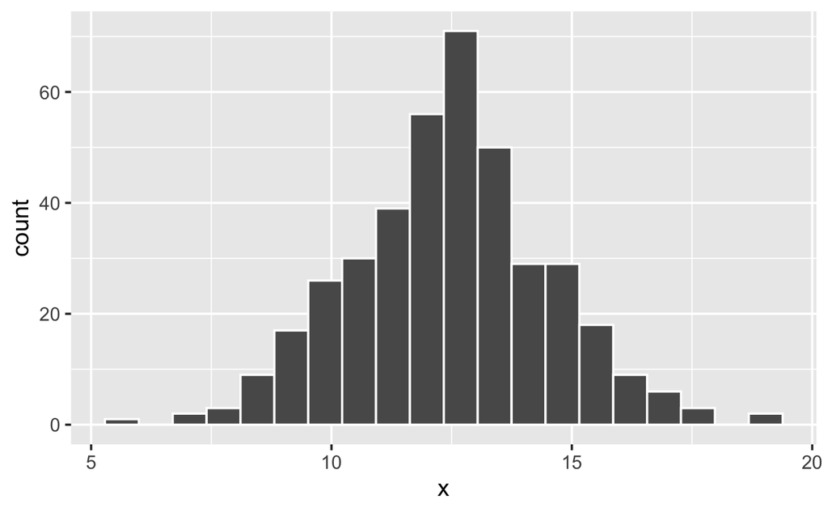

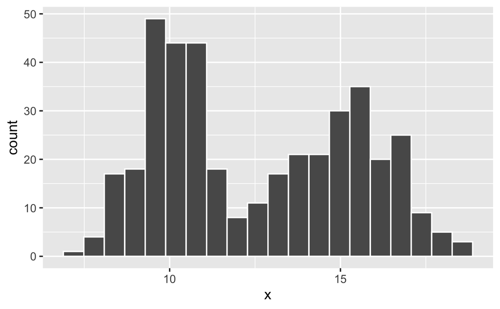

# Measures of centre with bimodal or multimodal data

In the bimodal data set, the mean and median actually fall around 12, which is in fact a low point in the data.

| mean | median |
| --- | --- |
| 12.56773 | 12.08936 |

# Skewness

Skewed: The peak falls to the left or right of the centre Skewness: a description of how skewed the data is, by looking at the relationship between mean and median Left-skewed, the tail is on the left.

```r
left_skewed <- read_csv("data/leftskew.csv")
```

| mean | median |
| --- | --- |
| 11.69079 | 11.8313 |

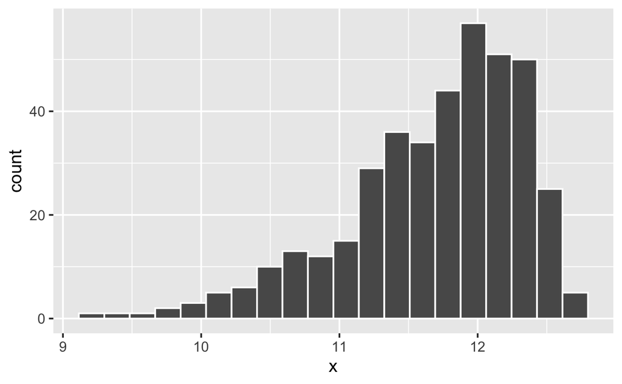

# Calculating mode with continuous data

| modal_value |
| --- |
| (11.9,12.1] |

### Pattern for left skewed data

Mean < Median < Mode

# Right skewed

Try the same process again for the right-skewed data below: right_skewed <- read_csv(“data/rightskew.csv”) Visualise the distribution. What order do the mean, median and mode fall in for right-skewed data?

```r
right_skewed <- read_csv("data/rightskew.csv")
```

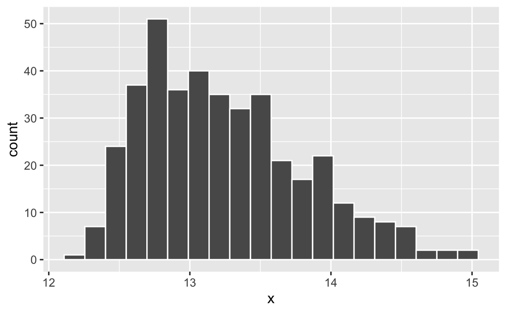

| mean | median | mode |
| --- | --- | --- |
| 13.24013 | 13.14153 | (12.7,12.8] |

Mean > Median > Mode

# Measuring skew

```r
library(e1071)
```

| skewness |
| --- |
| -1.011889 |

Left skewness measured with a negative number Right skewness measured with a positive number. The greater the value of the number, the more skewed the data 0 > 0.5 - not skewed 0.5 > 1 - moderately skewed 1 > - highly skewed

| skewness |
| --- |
| 0.6736541 |

| skewness |
| --- |
| 3.824317 |

Impact of outliers on skewness

| skewness |
| --- |
| 0.7188657 |